# Customer_Churn_test

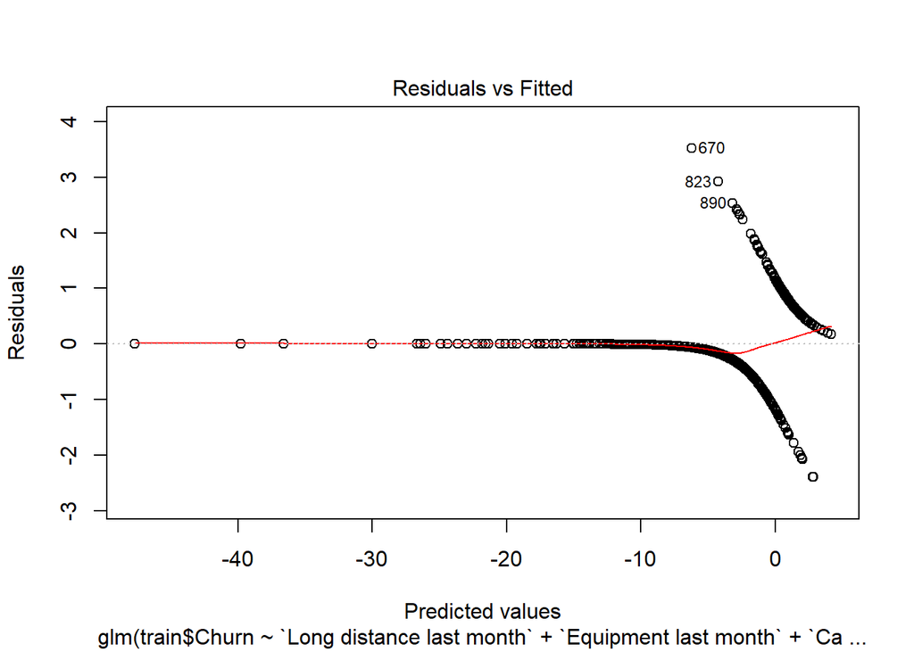

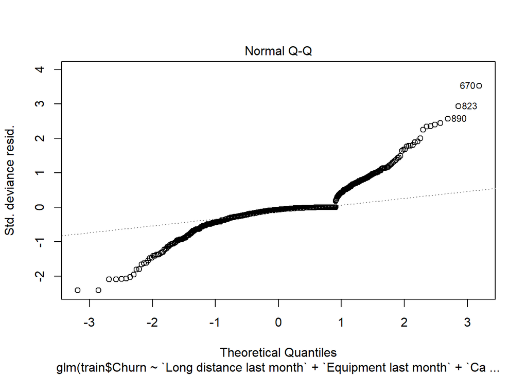

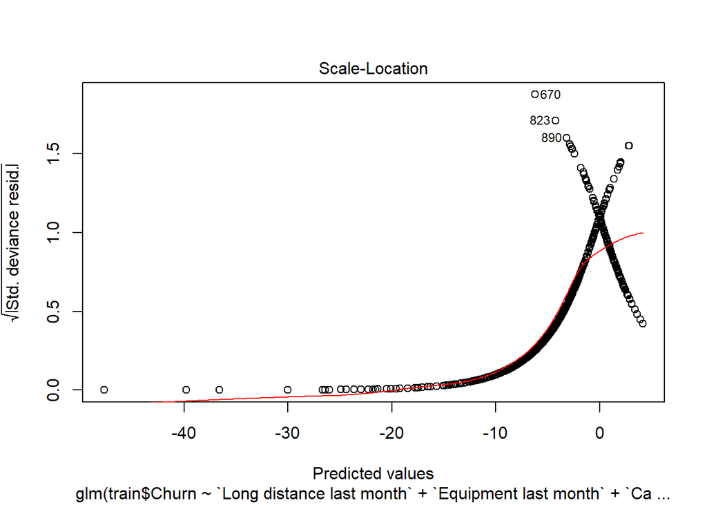

```r
plot(stepGLM3, which =c(1,2,3))
```

Looking at the rest of the diagnosis plots of residuals, even though there is good accuracy, the normality assumption is violated, and I am getting some confirmation of over fitted model in some parts. As there are patterns in the residuals and there are no sparse residuals vs fitted values, this can imply the coefficients and standard errors might not be very reliable.

Another graphical assessment can be checking observed values and fitted (predicted). I could assess the fit of the model by plotting the observed values vs the fitted values as shown below, but this is relatively uninformative since the response values are binary and the fitted values are probabilities. When the response values are proportions, this comparison is of more use. Cross checking the residual plots and the below plot, gives me a feeling of slight over-fit in parts of the data points.

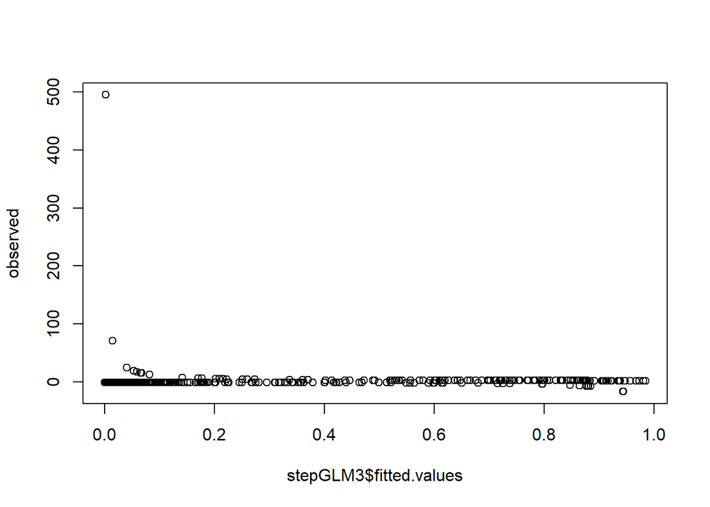

```r
observed <- stepGLM3$fitted.values + stepGLM3$residuals
plot(stepGLM3$fitted.values, observed)
```